# p8105_hw1_hz2770

Hao Zheng

2021/9/28

```r
library(tidyverse)
```

## Problem 1

This is a dataframe which contains four variables.

```r
example_df = tibble(
  norm_samp = rnorm(10),
  vec_logical = norm_samp > 0,
  vec_char = c("v","i","c","t","o","r","i","a","t","h"),
  vec_factor =c("low","medium","low","high","high","medium","low","high","medium","medium")
)
```

Then take the mean of each variable and see what will happen.

```r
x = pull(example_df,norm_samp)
mean(x)
```

```
## [1] 0.0909952
```

```r
y = pull(example_df,vec_logical)
mean(y)
```

```
## [1] 0.6
```

```r
z = pull(example_df,vec_char)
mean(z)
```

```
## [1] NA
```

```r
w = pull(example_df,vec_factor)
mean(w)
```

```
## [1] NA
```

Oops! We can only take the mean of the numeric and logical value in the dataframe, why is that?

Let’s try to apply as.numeric() fuction on all the variables.

```r
as.numeric(x)

as.numeric(y)

as.numeric(z)

as.numeric(w)
```

[output not shown]

## Problem 2

First, download a package containing the penguins dataset in the console. Then load this dataset.

```r
# load the penguins dataset
data("penguins", package = "palmerpenguins")
```

The dataset penguins contains 8 variables, among which, “species” and “island” are character variables; “bill_length_mm”, “bill_depth_mm”, “flipper_length_mm”, “body_mass_g” and “year” are numeric variables; “sex” is factor variable.

For the size of this dataset, `nrow = 344`, and `ncol = 8`, mean flipper length is 200.9152047.

Then we generate the scatter plot of `flipper_length_mm`(y) vs `bill_length_mm`(x) and color the points.

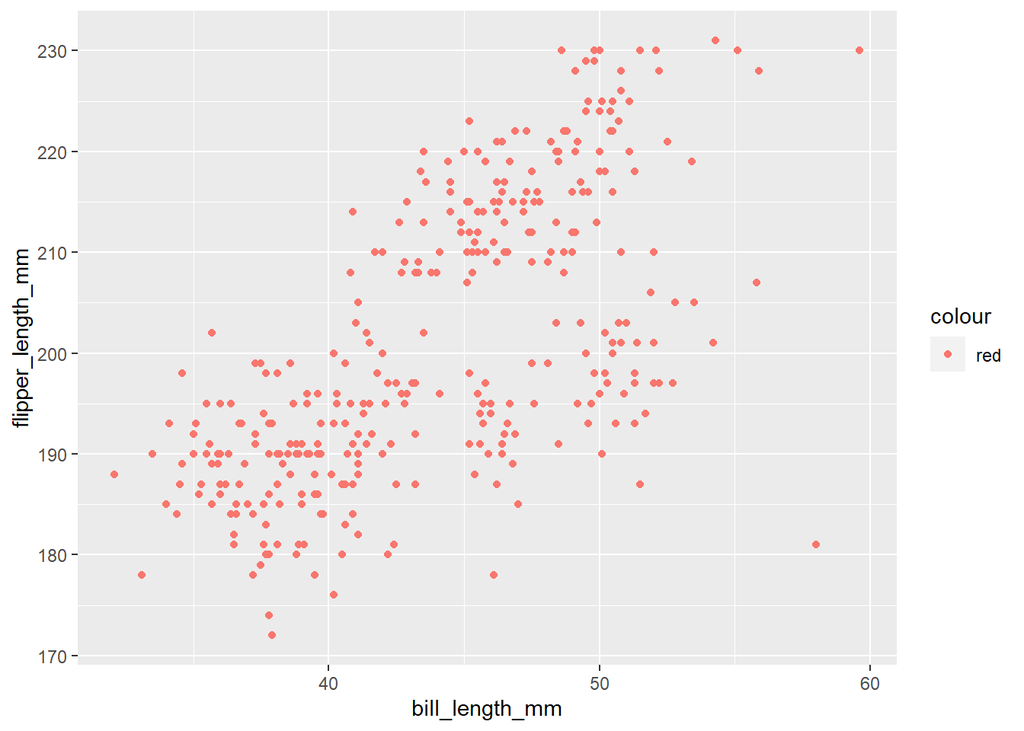

```r
#  Make a scatterplot
ggplot(penguins, aes(x = bill_length_mm, y = flipper_length_mm, color = "red")) + geom_point()
```

```r
ggsave("scatter_plot.png")
```